# [Portfolio] Sales Time Series 6

Part 5: https://colab.research.google.com/drive/1DJ-RdGu0WEjTorNWnqz5a70HZPARlZx0

Similar to part 4 this notebook won't run on google colab

## Loading Packages

```python
# Deactivating the multiple warning messages produced by the newest versions of Pandas and Matplotlib.import sys
import sys
import warnings
import matplotlib.cbook
if not sys.warnoptions:
    warnings.simplefilter("ignore")
warnings.simplefilter(action='ignore', category=FutureWarning)
warnings.filterwarnings("ignore", category=FutureWarning)
warnings.filterwarnings("ignore", category=matplotlib.cbook.mplDeprecation)

# Data manipulation imports
import numpy as np
import pandas as pd
import itertools
from pandas import Series

# Data visualization imports
import matplotlib.pyplot as plt
import matplotlib as m
import seaborn as sns
import plotly as py
import plotly.express as px
import plotly.graph_objs as go
from plotly.offline import download_plotlyjs, init_notebook_mode, plot, iplot

# Predictive modeling imports
import statsmodels
import statsmodels.api as sm
import statsmodels.tsa.api as smt
import statsmodels.stats as sms
import scipy
import scipy.stats as scs
from statsmodels.graphics import tsaplots
from statsmodels.tsa.seasonal import seasonal_decompose
from statsmodels.tsa.stattools import adfuller
from statsmodels.stats.stattools import jarque_bera
import fbprophet
from fbprophet import Prophet
import holidays

# Metrics and performance imports
import math
from math import sqrt
import sklearn
from sklearn.metrics import mean_squared_error

# Graphics formatting imports
m.rcParams['axes.labelsize'] = 14
m.rcParams['xtick.labelsize'] = 12
m.rcParams['ytick.labelsize'] = 12
m.rcParams['text.color'] = 'k'
from matplotlib.pylab import rcParams
rcParams['figure.figsize'] = 15,7
matplotlib.style.use('ggplot')
%matplotlib inline
```

```python
# Versions of the packages used
%reload_ext watermark
%watermark --iversions
```

```
sklearn         0.22.1
matplotlib      3.1.3
plotly          4.6.0
numpy           1.18.1
pandas          1.0.2
scipy           1.4.1
fbprophet       0.6
holidays        0.10.1
seaborn         0.10.0
statsmodels.api 0.11.0
statsmodels     0.11.0
```

## Data

The dataset used is available publicly in Tableau's website, and represents the historic sales from the startup in which HappyMoonVC is considering investing.

Dataset source: https://community.tableau.com/docs/DOC-1236

HappyMoonVC wants to analyze and predict all data the in the "technology" category

```python
# Load data
data = pd.read_csv('https://raw.githubusercontent.com/Matheus-Schmitz/Datasets/master/dataset6.csv')
```

```python
# Shape
data.shape
```

```
(9994, 21)
```

```python
# Columns
data.columns
```

```
Index(['Row ID', 'Order ID', 'Order Date', 'Ship Date', 'Ship Mode',
       'Customer ID', 'Customer Name', 'Segment', 'Country', 'City', 'State',
       'Postal Code', 'Region', 'Product ID', 'Category', 'Sub-Category',
       'Product Name', 'Sales', 'Quantity', 'Discount', 'Profit'],
      dtype='object')
```

## Exploratory Analysis

```python
# Visualizing data
data.head()
```

|  | Row ID | Order ID | Order Date | Ship Date | Ship Mode | Customer ID | Customer Name | Segment | Country | City | ... | Postal Code | Region | Product ID | Category | Sub-Category | Product Name | Sales | Quantity | Discount | Profit |
| --- | --- | --- | --- | --- | --- | --- | --- | --- | --- | --- | --- | --- | --- | --- | --- | --- | --- | --- | --- | --- | --- |
| 0 | 1 | CA-2016-152156 | 2016-11-08 | 2016-11-11 | Second Class | CG-12520 | Claire Gute | Consumer | United States | Henderson | ... | 42420 | South | FUR-BO-10001798 | Furniture | Bookcases | Bush Somerset Collection Bookcase | 261.9600 | 2 | 0.00 | 41.9136 |
| 1 | 2 | CA-2016-152156 | 2016-11-08 | 2016-11-11 | Second Class | CG-12520 | Claire Gute | Consumer | United States | Henderson | ... | 42420 | South | FUR-CH-10000454 | Furniture | Chairs | Hon Deluxe Fabric Upholstered Stacking Chairs,... | 731.9400 | 3 | 0.00 | 219.5820 |
| 2 | 3 | CA-2016-138688 | 2016-06-12 | 2016-06-16 | Second Class | DV-13045 | Darrin Van Huff | Corporate | United States | Los Angeles | ... | 90036 | West | OFF-LA-10000240 | Office Supplies | Labels | Self-Adhesive Address Labels for Typewriters b... | 14.6200 | 2 | 0.00 | 6.8714 |
| 3 | 4 | US-2015-108966 | 2015-10-11 | 2015-10-18 | Standard Class | SO-20335 | Sean O'Donnell | Consumer | United States | Fort Lauderdale | ... | 33311 | South | FUR-TA-10000577 | Furniture | Tables | Bretford CR4500 Series Slim Rectangular Table | 957.5775 | 5 | 0.45 | -383.0310 |
| 4 | 5 | US-2015-108966 | 2015-10-11 | 2015-10-18 | Standard Class | SO-20335 | Sean O'Donnell | Consumer | United States | Fort Lauderdale | ... | 33311 | South | OFF-ST-10000760 | Office Supplies | Storage | Eldon Fold 'N Roll Cart System | 22.3680 | 2 | 0.20 | 2.5164 |

5 rows × 21 columns

```python
# Statistic summaries
data.describe()
```

|  | Row ID | Postal Code | Sales | Quantity | Discount | Profit |
| --- | --- | --- | --- | --- | --- | --- |
| count | 9994.000000 | 9994.000000 | 9994.000000 | 9994.000000 | 9994.000000 | 9994.000000 |
| mean | 4997.500000 | 55190.379428 | 229.858001 | 3.789574 | 0.156203 | 28.656896 |
| std | 2885.163629 | 32063.693350 | 623.245101 | 2.225110 | 0.206452 | 234.260108 |
| min | 1.000000 | 1040.000000 | 0.444000 | 1.000000 | 0.000000 | -6599.978000 |
| 25% | 2499.250000 | 23223.000000 | 17.280000 | 2.000000 | 0.000000 | 1.728750 |
| 50% | 4997.500000 | 56430.500000 | 54.490000 | 3.000000 | 0.200000 | 8.666500 |
| 75% | 7495.750000 | 90008.000000 | 209.940000 | 5.000000 | 0.200000 | 29.364000 |
| max | 9994.000000 | 99301.000000 | 22638.480000 | 14.000000 | 0.800000 | 8399.976000 |

```python
# Checking for missing values
data.info()
```

```
<class 'pandas.core.frame.DataFrame'>
RangeIndex: 9994 entries, 0 to 9993
Data columns (total 21 columns):
 #   Column         Non-Null Count  Dtype
---  ------         --------------  -----
 0   Row ID         9994 non-null   int64
 1   Order ID       9994 non-null   object
 2   Order Date     9994 non-null   object
 3   Ship Date      9994 non-null   object
 4   Ship Mode      9994 non-null   object
 5   Customer ID    9994 non-null   object
 6   Customer Name  9994 non-null   object
 7   Segment        9994 non-null   object
 8   Country        9994 non-null   object
 9   City           9994 non-null   object
 10  State          9994 non-null   object
 11  Postal Code    9994 non-null   int64
 12  Region         9994 non-null   object
 13  Product ID     9994 non-null   object
 14  Category       9994 non-null   object
 15  Sub-Category   9994 non-null   object
 16  Product Name   9994 non-null   object
 17  Sales          9994 non-null   float64
 18  Quantity       9994 non-null   int64
 19  Discount       9994 non-null   float64
 20  Profit         9994 non-null   float64
dtypes: float64(3), int64(3), object(15)
memory usage: 1.6+ MB
```

```python
# Setting column names to lowercase
data.columns = map(str.lower, data.columns)
```

```python
# Substituting espaces and dashes in the column names by underscores
data.columns = data.columns.str.replace(" ", "_")
data.columns = data.columns.str.replace("-", "_")
```

```python
# Checking
data.columns
```

```
Index(['row_id', 'order_id', 'order_date', 'ship_date', 'ship_mode',
       'customer_id', 'customer_name', 'segment', 'country', 'city', 'state',
       'postal_code', 'region', 'product_id', 'category', 'sub_category',
       'product_name', 'sales', 'quantity', 'discount', 'profit'],
      dtype='object')
```

```python
# Assess the unique values per column (to know whether a variable is categorical or not)
for c in data.columns:
    if len(set(data[c])) < 20:
        print(c,set(data[c]))
```

```
ship_mode {'Same Day', 'First Class', 'Second Class', 'Standard Class'}
segment {'Corporate', 'Consumer', 'Home Office'}
country {'United States'}
region {'East', 'West', 'Central', 'South'}
category {'Office Supplies', 'Technology', 'Furniture'}
sub_category {'Envelopes', 'Labels', 'Storage', 'Copiers', 'Accessories', 'Bookcases', 'Art', 'Machines', 'Phones', 'Chairs', 'Appliances', 'Fasteners', 'Tables', 'Paper', 'Supplies', 'Furnishings', 'Binders'}
quantity {1, 2, 3, 4, 5, 6, 7, 8, 9, 10, 11, 12, 13, 14}
discount {0.0, 0.8, 0.2, 0.3, 0.45, 0.5, 0.7, 0.6, 0.32, 0.1, 0.4, 0.15}
```

```python
# Splitting data by category
df_technology = data.loc[data['category'] == 'Technology']
df_furniture = data.loc[data['category'] == 'Furniture']
df_office = data.loc[data['category'] == 'Office Supplies']
```

Agora vamos preparar as séries temporais.

```python
# Aggregating sales by order date
ts_technology = df_technology.groupby('order_date')['sales'].sum().reset_index()
ts_furniture = df_furniture.groupby('order_date')['sales'].sum().reset_index()
ts_office = df_office.groupby('order_date')['sales'].sum().reset_index()
```

```python
# Checking dataset
ts_technology
```

|  | order_date | sales |
| --- | --- | --- |
| 0 | 2014-01-06 | 1147.940 |
| 1 | 2014-01-09 | 31.200 |
| 2 | 2014-01-13 | 646.740 |
| 3 | 2014-01-15 | 149.950 |
| 4 | 2014-01-16 | 124.200 |
| ... | ... | ... |
| 819 | 2017-12-25 | 401.208 |
| 820 | 2017-12-27 | 164.388 |
| 821 | 2017-12-28 | 14.850 |
| 822 | 2017-12-29 | 302.376 |
| 823 | 2017-12-30 | 90.930 |

824 rows × 2 columns

```python
# Setting the date as index
ts_technology = ts_technology.set_index('order_date')
ts_furniture = ts_furniture.set_index('order_date')
ts_office = ts_office.set_index('order_date')
```

```python
# Visualizing the series
ts_technology
```

| order_date | sales |
| --- | --- |
| 2014-01-06 | 1147.940 |
| 2014-01-09 | 31.200 |
| 2014-01-13 | 646.740 |
| 2014-01-15 | 149.950 |
| 2014-01-16 | 124.200 |
| ... | ... |
| 2017-12-25 | 401.208 |
| 2017-12-27 | 164.388 |
| 2017-12-28 | 14.850 |
| 2017-12-29 | 302.376 |
| 2017-12-30 | 90.930 |

824 rows × 1 columns

Agora podemos conferir a performance de vendas ao longo do tempo.

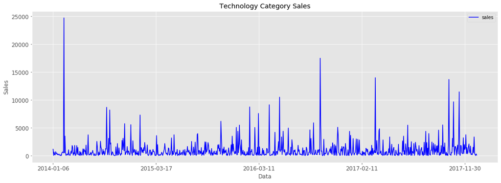

```python
# Plotting sales in the technology category
sales_technology = ts_technology[['sales']]
ax = sales_technology.plot(color = 'b', figsize = (18,6))
plt.xlabel("Data")
plt.ylabel('Sales')
plt.title("Technology Category Sales")
plt.show()
```

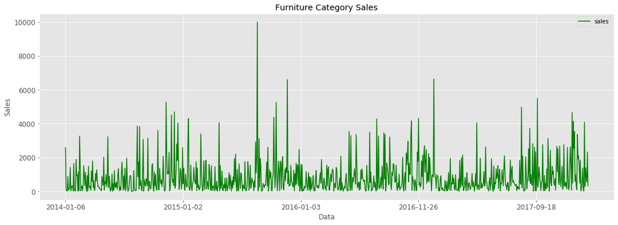

```python
# Plotting sales in the furniture category
sales_furniture = ts_furniture[['sales']]
ax = sales_furniture.plot(color = 'g', figsize = (18,6))
plt.xlabel("Data")
plt.ylabel('Sales')
plt.title("Furniture Category Sales")
plt.show()
```

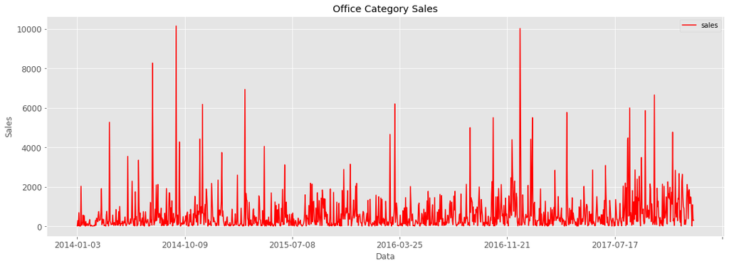

```python
# Plotting sales in the office category
sales_office = ts_office[['sales']]
ax = sales_office.plot(color = 'r', figsize = (18,6))
plt.xlabel("Data")
plt.ylabel('Sales')
plt.title("Office Category Sales")
plt.show()
```

```python
# Checking index type
type(sales_technology.index)
```

```
pandas.core.indexes.base.Index
```

```python
# Changing index type
sales_technology.index = pd.to_datetime(sales_technology.index)
sales_furniture.index = pd.to_datetime(sales_furniture.index)
sales_office.index = pd.to_datetime(sales_office.index)
```

```python
# Checking index type
type(sales_technology.index)
```

```
pandas.core.indexes.datetimes.DatetimeIndex
```

```python
# Resampling data to a monthly frequency
# Done by setting the month as index and then calculating the mean of daily sales over the month
sales_technology_monthly_mean = sales_technology['sales'].resample('MS').mean()
sales_furniture_monthly_mean = sales_furniture['sales'].resample('MS').mean()
sales_office_monthly_mean = sales_office['sales'].resample('MS').mean()
```

```python
# Verifying the resulting type
type(sales_technology_monthly_mean)
```

```
pandas.core.series.Series
```

```python
# Checking the data
sales_technology_monthly_mean
```

```
order_date
2014-01-01     449.041429
2014-02-01     229.787143
2014-03-01    2031.948375
2014-04-01     613.028933
2014-05-01     564.698588
2014-06-01     766.905909
2014-07-01     533.608933
2014-08-01     708.435385
2014-09-01    2035.838133
2014-10-01     596.900900
2014-11-01    1208.056320
2014-12-01    1160.732889
2015-01-01     925.070800
2015-02-01     431.121250
2015-03-01     574.662333
2015-04-01     697.559500
2015-05-01     831.642857
2015-06-01     429.024400
2015-07-01     691.397733
2015-08-01    1108.902286
2015-09-01     950.856400
2015-10-01     594.716111
2015-11-01    1037.982652
2015-12-01    1619.637636
2016-01-01     374.671067
2016-02-01    1225.891400
2016-03-01    1135.150105
2016-04-01     875.911882
2016-05-01    1601.816167
2016-06-01    1023.259500
2016-07-01     829.312500
2016-08-01     483.620100
2016-09-01    1144.170300
2016-10-01    1970.835875
2016-11-01    1085.642360
2016-12-01     970.554870
2017-01-01    1195.218071
2017-02-01     430.501714
2017-03-01    1392.859250
2017-04-01     825.559133
2017-05-01     678.329400
2017-06-01     853.055000
2017-07-01    1054.996636
2017-08-01     978.842333
2017-09-01    1077.704120
2017-10-01    1493.439227
2017-11-01    1996.750920
2017-12-01     955.865652
Freq: MS, Name: sales, dtype: float64
```

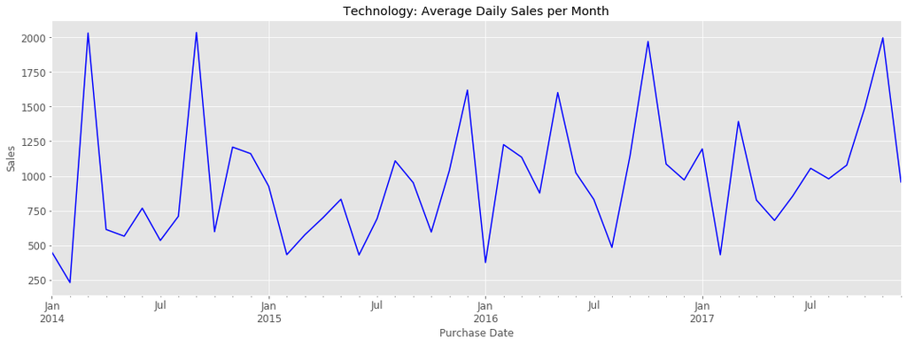

```python
# Plotting the monthly mean daily sales of technology products
sales_technology_monthly_mean.plot(figsize = (18, 6), color = 'blue')
plt.xlabel("Purchase Date")
plt.ylabel('Sales')
plt.title("Technology: Average Daily Sales per Month")
plt.show()
```

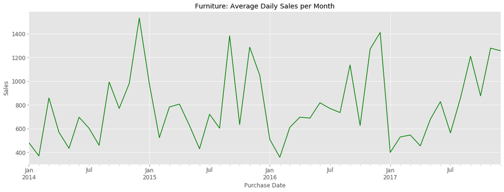

```python
# Plotting the monthly mean daily sales of furniture products
sales_furniture_monthly_mean.plot(figsize = (18, 6), color = 'green')
plt.xlabel("Purchase Date")
plt.ylabel('Sales')
plt.title("Furniture: Average Daily Sales per Month")
plt.show()
```

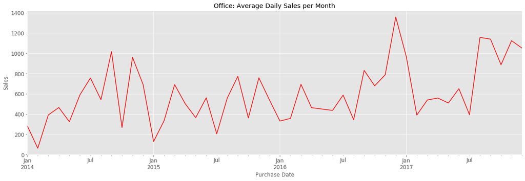

```python
# Plotting the monthly mean daily sales of office products
sales_office_monthly_mean.plot(figsize = (20, 6), color = 'red')
plt.xlabel("Purchase Date")
plt.ylabel('Sales')
plt.title("Office: Average Daily Sales per Month")
plt.show()
```

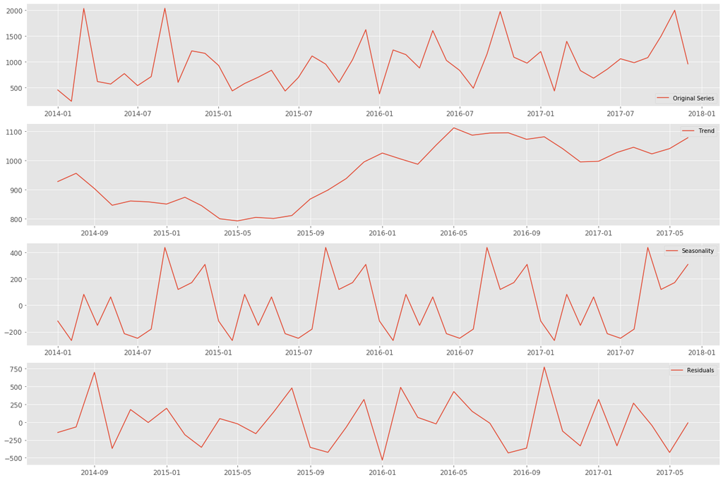

```python
# Decomposing the time series with the monthly mean daily sales of technology products
decomposition = seasonal_decompose(sales_technology_monthly_mean, freq = 12)
rcParams['figure.figsize'] = 18, 12

# Components
trend = decomposition.trend
seasonal = decomposition.seasonal
residual = decomposition.resid

# Plot
plt.subplot(411)
plt.plot(sales_technology_monthly_mean, label = 'Original Series')
plt.legend(loc = 'best')
plt.subplot(412)
plt.plot(trend, label = 'Trend')
plt.legend(loc = 'best')
plt.subplot(413)
plt.plot(seasonal, label = 'Seasonality')
plt.legend(loc = 'best')
plt.subplot(414)
plt.plot(residual, label = 'Residuals')
plt.legend(loc = 'best')
plt.tight_layout()
```

Stationarity test:

```python
# Function to test stationarity
def stationarity_test(serie):

    # Calculating moving statistics
    rolmean = serie.rolling(window = 12).mean()
    rolstd = serie.rolling(window = 12).std()

    # Plot of moving statistics
    orig = plt.plot(serie, color = 'blue', label = 'Original')
    mean = plt.plot(rolmean, color = 'red', label = 'Moving Average')
    std = plt.plot(rolstd, color = 'black', label = 'Standard Deviation')
    plt.legend(loc = 'best')
    plt.title('Moving Statistics - Mean and Standard Deviation')
    plt.show()

    # Dickey-Fuller test:
    # Print
    print('\nDickey-Fuller Test Result:\n')

    # Test
    dftest = adfuller(serie, autolag = 'AIC')

    # Formatting the output
    df_output = pd.Series(dftest[0:4], index = ['Test Statistic',
                                               'P-value',
                                               'Number of Lags Considered',
                                               'Number of Observations Used'])

    # Loop through each item in the test output
    for key, value in dftest[4].items():
        df_output['Critical Value (%s)'%key] = value

    # Print
    print (df_output)

    # Testing p-value
    print ('\nConclusion:')
    if df_output[1] > 0.05:
        print('\nThe p-value is above 0.05, therefore there are no evidences to reject the null hypothesis.')
        print('This series probably is not stationary.')
    else:
        print('\nThe p-value is below 0.05, therefore there are evidences to reject the null hypothesis.')
        print('This series probably is stationary.')
```

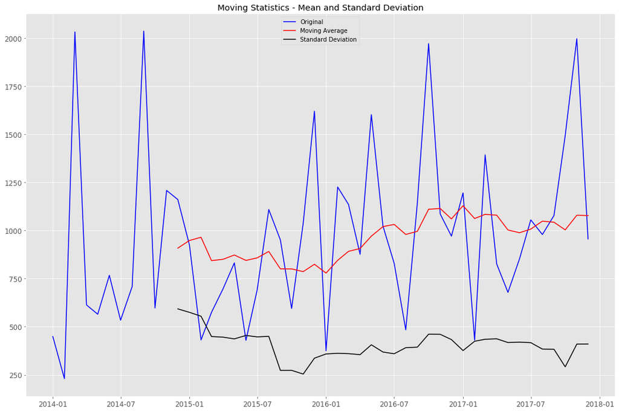

```
Dickey-Fuller Test Result:

Test Statistic                -7.187969e+00
P-value                        2.547334e-10
Number of Lags Considered      0.000000e+00
Number of Observations Used    4.700000e+01
Critical Value (1%)           -3.577848e+00
Critical Value (5%)           -2.925338e+00
Critical Value (10%)          -2.600774e+00
dtype: float64

Conclusion:

The p-value is below 0.05, therefore there are evidences to reject the null hypothesis.
This series probably is stationary.
```

```python
# Verifying if the series is stationary
stationarity_test(sales_technology_monthly_mean)
```

## Function to Calculate Accuracy

```python
# Function
def performance(y_true, y_pred):
    mse = ((y_pred - y_true) ** 2).mean()
    mape = np.mean(np.abs((y_true - y_pred) / y_true)) * 100
    return( print('The prediction MSE is {}'.format(round(mse, 2))+
                  '\nThe prediction RMSE is {}'.format(round(np.sqrt(mse), 2))+
                  '\nThe prediction MAPE is {}'.format(round(mape, 2))))
```

## Prophet Model

Prophet holiday documentation:

https://facebook.github.io/prophet/docs/seasonality,_holiday_effects,_and_regressors.html

To include holidays and other recurring events into a time series model with Prophet it's necessary to create an additional dataframe to feed the model.

Prophet requires a dataframe with two columns (holiday and ds) and a row for each occurance of the holiday. The dataframe must include all occurances of the holiday, both in the past and in all future dates the model is expected to predict.

It's also possible to include the columns lower_window and upper_window, which extend the holiday to [lower_window, upper_window] days around the date. Essentially a way of indicating extended holidays.

Since this analysis is being conducted on a monthly time series, it doesn't necessarily make sense to include holidays, nevertheless I'm option to include it here as in Prophet's case this variable should not negatively influence the model, plus this could easiy be reverted by emptying the holiday dataframe right before feeding it into the algorithm training process.

Prophet requires that the date column be named 'ds' and the target column be named 'y'

```python
# Load data
data = pd.read_csv('https://raw.githubusercontent.com/dsacademybr/Datasets/master/dataset6.csv')

# Setting column names to lowercase
data.columns = map(str.lower, data.columns)

# Substituting espaces and dashes in the column names by underscores
data.columns = data.columns.str.replace(" ", "_")
data.columns = data.columns.str.replace("-", "_")

# Splitting data by category
df_technology = data.loc[data['category'] == 'Technology']

# Aggregating sales by order date
ts_technology = df_technology.groupby('order_date')['sales'].sum().reset_index()

# Setting the date as index
ts_technology = ts_technology.set_index('order_date')

# Retrieving only sales data
sales_technology = ts_technology[['sales']]

# Changing index type
sales_technology.index = pd.to_datetime(sales_technology.index)

# Resampling data to a monthly frequency
# Done by setting the month as index and then calculating the mean of daily sales over the month
sales_technology_monthly_mean = sales_technology['sales'].resample('MS').mean()

# Train-Test Split
X = sales_technology_monthly_mean
train_size = int(len(X) * 0.75)
trainset, testset = X[0:train_size], X[train_size:]
```

```python
# Dataframe with holidays
holidays_df = pd.DataFrame([])
for date, name in sorted(holidays.UnitedStates(years=[2014,2015,2016,2017]).items()):
    holidays_df = holidays_df.append(pd.DataFrame({'ds': date, 'holiday': name}, index=[0]), ignore_index=True)
holidays_df['ds'] = pd.to_datetime(holidays_df['ds'], format='%Y-%m-%d', errors='ignore')
```

```python
# Creating dataframes for train and test data
df_train = pd.DataFrame({'order_date':trainset.index, 'sales':trainset.values})
df_test = pd.DataFrame({'order_date':testset.index, 'sales':testset.values})
```

```python
# Renaming columns: Prophet requires columns to be names 'ds' and 'y'
df_train = df_train.rename(columns = {'order_date': 'ds', 'sales': 'y'})
df_test = df_test.rename(columns = {'order_date': 'ds', 'sales': 'y'})
```

```python
# Create a Prophet model with annual seasonalisty and the holidays dataframe
prophet_model = Prophet(yearly_seasonality = True, holidays = holidays_df)
```

https://facebook.github.io/prophet/docs/seasonality,_holiday_effects,_and_regressors.html#built-in-country-holidays

Using Prophet's built-in country holiday module, which allows for easy inclusion of holidays into a prophet model for future prediction.

```python
# Adding the built-in Country Holiday method to the model
prophet_model.add_country_holidays(country_name = 'US')
```

```
<fbprophet.forecaster.Prophet at 0x12592a2f2c8>
```

```python
# Training
prophet_model.fit(df_train)
```

```
INFO:numexpr.utils:NumExpr defaulting to 8 threads.
INFO:fbprophet:Disabling weekly seasonality. Run prophet with weekly_seasonality=True to override this.
INFO:fbprophet:Disabling daily seasonality. Run prophet with daily_seasonality=True to override this.
```

```
<fbprophet.forecaster.Prophet at 0x12592a2f2c8>
```

```python
# Creating dataframe to fill with predictions
prophet_predictions_df = prophet_model.make_future_dataframe(periods = 12, freq = 'MS')
prophet_predictions_df.count()
```

```
ds    48
dtype: int64
```

```python
# Forecast
prophet_model_predictions = prophet_model.predict(prophet_predictions_df)
```

```python
# Checking predictions
prophet_model_predictions[['ds', 'yhat', 'yhat_lower', 'yhat_upper']].tail()
```

|  | ds | yhat | yhat_lower | yhat_upper |
| --- | --- | --- | --- | --- |
| 43 | 2017-08-01 | 790.707493 | 484.867321 | 1067.218295 |
| 44 | 2017-09-01 | 1218.777399 | 935.403515 | 1526.101526 |
| 45 | 2017-10-01 | 1566.094807 | 1283.662932 | 1862.724268 |
| 46 | 2017-11-01 | 1315.903616 | 1021.928630 | 1608.573564 |
| 47 | 2017-12-01 | 1343.235536 | 1062.583906 | 1639.685340 |

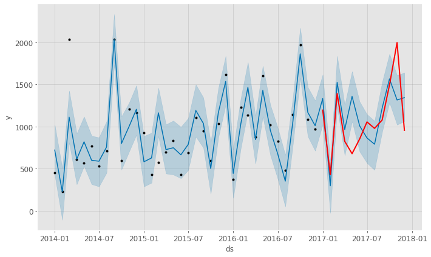

```python
# Creating a plot to visualize predictions

# Plot predictions
fig = prophet_model.plot(prophet_model_predictions)

# Plot actual sales data in red
plt.plot(testset, label = 'Test', color = 'red', linewidth = 2)
plt.show()
```

```python
# Checking the entire output dataframe
prophet_model_predictions.head()
```

|  | ds | trend | yhat_lower | yhat_upper | trend_lower | trend_upper | Christmas Day | Christmas Day_lower | Christmas Day_upper | Christmas Day (Observed) | ... | holidays | holidays_lower | holidays_upper | yearly | yearly_lower | yearly_upper | multiplicative_terms | multiplicative_terms_lower | multiplicative_terms_upper | yhat |
| --- | --- | --- | --- | --- | --- | --- | --- | --- | --- | --- | --- | --- | --- | --- | --- | --- | --- | --- | --- | --- | --- |
| 0 | 2014-01-01 | 925.615140 | 426.714320 | 1023.872644 | 925.615140 | 925.615140 | 0.0 | 0.0 | 0.0 | 0.0 | ... | -860.551899 | -860.551899 | -860.551899 | 657.249847 | 657.249847 | 657.249847 | 0.0 | 0.0 | 0.0 | 722.313088 |
| 1 | 2014-02-01 | 935.580148 | -107.551269 | 507.486660 | 935.580148 | 935.580148 | 0.0 | 0.0 | 0.0 | 0.0 | ... | 0.000000 | 0.000000 | 0.000000 | -709.376814 | -709.376814 | -709.376814 | 0.0 | 0.0 | 0.0 | 226.203335 |
| 2 | 2014-03-01 | 944.580801 | 810.034040 | 1426.133777 | 944.580801 | 944.580801 | 0.0 | 0.0 | 0.0 | 0.0 | ... | 0.000000 | 0.000000 | 0.000000 | 167.586268 | 167.586268 | 167.586268 | 0.0 | 0.0 | 0.0 | 1112.167068 |
| 3 | 2014-04-01 | 954.545809 | 313.827314 | 916.950991 | 954.545809 | 954.545809 | 0.0 | 0.0 | 0.0 | 0.0 | ... | 0.000000 | 0.000000 | 0.000000 | -341.771264 | -341.771264 | -341.771264 | 0.0 | 0.0 | 0.0 | 612.774545 |
| 4 | 2014-05-01 | 964.189365 | 530.791563 | 1118.642531 | 964.189365 | 964.189365 | 0.0 | 0.0 | 0.0 | 0.0 | ... | 0.000000 | 0.000000 | 0.000000 | -145.341319 | -145.341319 | -145.341319 | 0.0 | 0.0 | 0.0 | 818.848046 |

5 rows × 61 columns

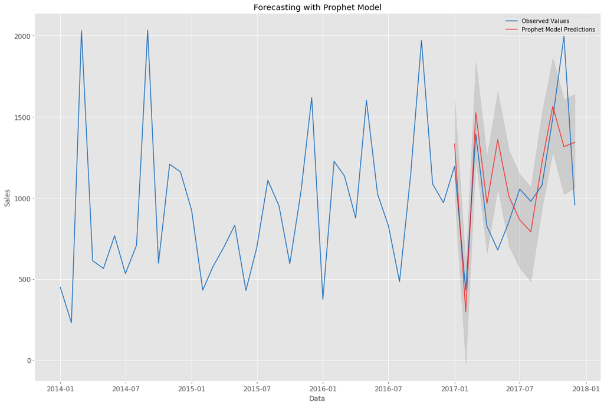

```python
# Plot

# Original series
plt.plot(sales_technology_monthly_mean.index,
         sales_technology_monthly_mean.values,
         label = 'Observed Values',
         color = '#2574BF')

# Predictions
plt.plot(sales_technology_monthly_mean[36:48].index,
         prophet_model_predictions[36:48]['yhat'].values,
         label = 'Prophet Model Predictions',
         alpha = 0.7,
         color = 'red')

# Confidence intervals
plt.fill_between(sales_technology_monthly_mean[36:48].index,
                 prophet_model_predictions[36:48]['yhat_lower'].values,
                 prophet_model_predictions[36:48]['yhat_upper'].values,
                 color = 'k',
                 alpha = 0.1)

plt.title('Forecasting with Prophet Model')
plt.xlabel('Data')
plt.ylabel('Sales')
plt.legend()
plt.show()
```

Using prophet_model_predictions[36:48] since the goal is to predict only the sales for the months with werent used to train the Prophet model - in the case the year 2017.

```python
# Calculating performance
prophet_results = performance(testset.values, prophet_model_predictions[36:48]['yhat'])
prophet_results
```

```
The prediction MSE is 105965.29
The prediction RMSE is 325.52
The prediction MAPE is 26.45
```

Model comparison:

**ARMA (3,1):**

> - The prediction MSE is 168192.9
> - The prediction RMSE is 410.11
> - The prediction MAPE is 28.4

**ARIMA (6,0,4):**

> - The prediction MSE is 120137.97
> - The prediction RMSE is 346.61
> - The prediction MAPE is 20.1

**SARIMA (0,0,1)x(1,1,0,12):**

> - The prediction MSE is 184433.09
> - The prediction RMSE is 429.46
> - The prediction MAPE is 35.35

**SARIMA (1,1,1)x(1,1,0,12):**

> - The prediction MSE is 229093.55
> - The prediction RMSE is 478.64
> - The prediction MAPE is 47.48

**SARIMAX (1,1,1)x(1,1,0,12):**

> - The prediction MSE is 231232.42
> - The prediction RMSE is 480.87
> - The prediction MAPE is 47.99

**Prophet:**

> - The prediction MSE is 105965.29
> - The prediction RMSE is 325.52
> - The prediction MAPE is 26.45

## Deploy to Production

```python
# Using the pickle package to serialize the model and save in the hard drive
import pickle
```

```python
# Saving in the 'model' folder
with open('model/prophet_model.pckl', 'wb') as fout:
    pickle.dump(prophet_model, fout)
```

The model will be deployed with the Flask framework.

```python
# Install Flask
# !pip install -q -U flask
```

```python
# Using flask_cors, to handle CORS (Cross Origin Resource Sharing)
# !pip install -q -U flask_cors
```

```python
# Imports
import flask
import flask_cors
from flask import Flask, jsonify, request
from flask_cors import CORS, cross_origin
```

```python
# Versions of the packages used
%reload_ext watermark
%watermark --iversions
```

```
sklearn         0.22.1
matplotlib      3.1.3
plotly          4.6.0
numpy           1.18.1
pandas          1.0.2
scipy           1.4.1
fbprophet       0.6
holidays        0.10.1
flask_cors      3.0.8
seaborn         0.10.0
flask           1.1.1
statsmodels.api 0.11.0
statsmodels     0.11.0
```

Checking how the predictions from the trained model are made. First loading the model, then creating a dataframe with the number of periods to forecast, and then filling it. Doing this to check if the model is working properly.

```python
# Loading the model
with open('model/prophet_model.pckl', 'rb') as fin:
    prophet_model_prod = pickle.load(fin)
```

```python
# Testing the model before deployment
# Creating the predictions dataframe
dataframe_forecast = prophet_model_prod.make_future_dataframe(periods = 60, freq = 'MS')
```

```python
# Predicting
model_forecast = prophet_model_prod.predict(dataframe_forecast)
```

```python
# Printing the last predictions
model_forecast[['ds', 'yhat', 'yhat_lower', 'yhat_upper']].tail()
```

|  | ds | yhat | yhat_lower | yhat_upper |
| --- | --- | --- | --- | --- |
| 91 | 2021-08-01 | 1260.348681 | 964.962672 | 1553.849069 |
| 92 | 2021-09-01 | 1688.418587 | 1402.833170 | 2004.778531 |
| 93 | 2021-10-01 | 2035.735996 | 1726.354399 | 2339.011576 |
| 94 | 2021-11-01 | 1785.544805 | 1497.756984 | 2067.564820 |
| 95 | 2021-12-01 | 1812.876724 | 1525.332339 | 2124.678723 |

The prediction procedure works. Time to create the Flask app.

```python
# Imports
import os
import pickle
from pathlib import Path
from flask import Flask, render_template

# Instance a Flask app
app = Flask(__name__)

# Convert the app to CORS (Cross Origin Ressource Sharing)
CORS(app)

# Creating the root (/) which will be shown the the app is opened in a navigator (essentially just showing the index.html page)

@app.route("/")
def main_page():
    return render_template("index.html")

# When the user accesses the start page it will be requested to insert the number of periods it wishes to forecast.

# The index.html page will send (via POST method) the parameter the used typed and will call the forecast page.
# This page executes the forecast function below, which makes the predictions and returns an html table with the results.


@app.route("/forecast", methods = ['POST'])

# Forecast
def forecast():

    # Verify if the method is POST
    if request.method == 'POST':

        # From the form, colect the value in the horizon variable
        prediction_horizon = int(request.form['horizon'])

        # Loading the model
        with open('modelo/modelo_prophet.pckl', 'rb') as fin:
            prophet_model_prod = pickle.load(fin)

        # Creating a dataframe with the number of periods requested by the user
        df_app = prophet_model_prod.make_future_dataframe(periods = prediction_horizon, freq = 'MS')

        # Predicting
        forecast_app = prophet_model_prod.predict(df_app)

        # Storing the predictions on another object, returning only the month and the predicted mean daily sales
        df_app_predictions = forecast_app[['ds', 'yhat']][-prediction_horizon:]

        # Saving the html file
        df_app_predictions.to_html('templates/previsoes.html')
        html = df_app_predictions.to_html()

    # Return
    return html
```

```python
# Running the app on http://localhost:3000
if __name__ == "__main__":
    app.run(debug = False, host = '0.0.0.0', port = 3000)
```

```
 * Serving Flask app "__main__" (lazy loading)
 * Environment: production
   WARNING: This is a development server. Do not use it in a production deployment.
   Use a production WSGI server instead.
 * Debug mode: off
```

[output not shown]

While the cell above is running the model will be available at: http://localhost:3000

All the user needs to do is insert a number and the model will predict that many months ahead. There is no error treatment.